# Pandas and Seaborn based homework

DSE5002

## Beija Richardson 3/30/25

We will be working with the heart.csv data set

https://www.kaggle.com/fedesoriano/heart-failure-prediction?select=heart.csv

using tools in pandas and seaborn, and ideas from the two Jupyter notebooks we've seen this week

```python
!pip install seaborn
import pandas as pd
import numpy as np
import seaborn as sns
import p9
```

[output not shown]

```python
# make sure heart.csv is in your current working directory, or list the full path name in the variable infile

infile="C:/Users/Luke/Documents/Class5002/Module_2/Practice Exercises\\heart.csv"

bp_df=pd.read_csv(r"C:/Users/Luke/Documents/Class5002/Module_2/Practice Exercises/heart.csv")
bp_df.head()
```

|  | Age | Sex | ChestPainType | RestingBP | Cholesterol | FastingBS | RestingECG | MaxHR | ExerciseAngina | Oldpeak | ST_Slope | HeartDisease |
| --- | --- | --- | --- | --- | --- | --- | --- | --- | --- | --- | --- | --- |
| 0 | 40 | M | ATA | 140 | 289 | 0 | Normal | 172 | N | 0.0 | Up | 0 |
| 1 | 49 | F | NAP | 160 | 180 | 0 | Normal | 156 | N | 1.0 | Flat | 1 |
| 2 | 37 | M | ATA | 130 | 283 | 0 | ST | 98 | N | 0.0 | Up | 0 |
| 3 | 48 | F | ASY | 138 | 214 | 0 | Normal | 108 | Y | 1.5 | Flat | 1 |
| 4 | 54 | M | NAP | 150 | 195 | 0 | Normal | 122 | N | 0.0 | Up | 0 |

Find or create the following

a.) -Find the dimensions, memory used, and other basic information

b.) -Run the data summary

c.) Change the appropriate variables to type Categorical

d.) -Create a pivot table (using the Pandas groupby operation) showing mean Resting BP by Sex, Resting ECG and HeartDisease-What does this tell you? What else can you figure out using a Pivot table, show me two other helpful pivot tables based on different variables, different groupings or different aggregation functions (count, mean, max etc)

e.) -Show a histogram and the ECDF (empirical cumulative distribution function) for several continuous variables in the data set, in broad terms, what do the distributions look like, normal? exponential, poison-like?, uniform? Does this match your expectations?

```
https://seaborn.pydata.org/generated/seaborn.ecdfplot.html
https://matplotlib.org/stable/api/_as_gen/matplotlib.pyplot.ecdf.html
```

f.) -Show An SNS Pairplot, the most informative version you can find, set the hue based on Heart Disease, try using at least one other variable as the Hue. Discuss what you think you are seeing in this plot

Create all these results in this Notebook and turn it in

## Responses

```python
print(bp_df.shape)
```

```
(918, 12)
```

```python
bp_df.memory_usage(deep=True)
```

```
Index               132
Age                7344
Sex               45900
ChestPainType     47690
RestingBP          7344
Cholesterol        7344
FastingBS          7344
RestingECG        49214
MaxHR              7344
ExerciseAngina    45900
Oldpeak            7344
ST_Slope          47864
HeartDisease       7344
dtype: int64
```

```python
bp_df.describe()
```

|  | Age | RestingBP | Cholesterol | FastingBS | MaxHR | Oldpeak | HeartDisease |
| --- | --- | --- | --- | --- | --- | --- | --- |
| count | 918.000000 | 918.000000 | 918.000000 | 918.000000 | 918.000000 | 918.000000 | 918.000000 |
| mean | 53.510893 | 132.396514 | 198.799564 | 0.233115 | 136.809368 | 0.887364 | 0.553377 |
| std | 9.432617 | 18.514154 | 109.384145 | 0.423046 | 25.460334 | 1.066570 | 0.497414 |
| min | 28.000000 | 0.000000 | 0.000000 | 0.000000 | 60.000000 | -2.600000 | 0.000000 |
| 25% | 47.000000 | 120.000000 | 173.250000 | 0.000000 | 120.000000 | 0.000000 | 0.000000 |
| 50% | 54.000000 | 130.000000 | 223.000000 | 0.000000 | 138.000000 | 0.600000 | 1.000000 |
| 75% | 60.000000 | 140.000000 | 267.000000 | 0.000000 | 156.000000 | 1.500000 | 1.000000 |
| max | 77.000000 | 200.000000 | 603.000000 | 1.000000 | 202.000000 | 6.200000 | 1.000000 |

```python
print(bp_df.nunique())
```

```
Age                50
Sex                 2
ChestPainType       4
RestingBP          67
Cholesterol       222
FastingBS           2
RestingECG          3
MaxHR             119
ExerciseAngina      2
Oldpeak            53
ST_Slope            3
HeartDisease        2
dtype: int64
```

```python
pivot_table_1 = bp_df.groupby(['Sex', 'RestingECG', 'HeartDisease'])['RestingBP'].mean().reset_index()
```

```python
print(pivot_table_1)
```

```
   Sex RestingECG  HeartDisease   RestingBP
0    F        LVH             0  128.696970
1    F        LVH             1  148.928571
2    F     Normal             0  129.123596
3    F     Normal             1  139.310345
4    F         ST             0  127.523810
5    F         ST             1  139.285714
6    M        LVH             0  131.836735
7    M        LVH             1  135.467391
8    M     Normal             0  129.921348
9    M     Normal             1  130.675781
10   M         ST             0  134.275000
11   M         ST             1  137.727273
```

```python
continuous_vars = ['Age', 'RestingBP', 'Cholesterol', 'MaxHR']
```

```python
pip install matplotlib seaborn numpy
```

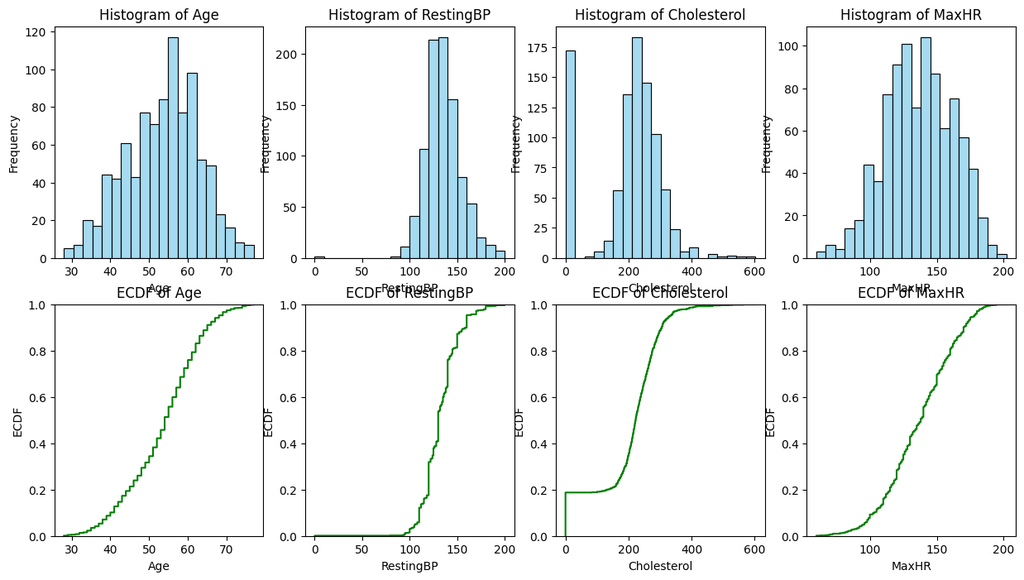

```python
import matplotlib.pyplot as plt
fig, axes = plt.subplots(2, len(continuous_vars), figsize=(15, 8))
continuous_vars = ['Age', 'RestingBP', 'Cholesterol', 'MaxHR']
for i, var in enumerate(continuous_vars):
    sns.histplot(bp_df[var], kde=False, ax=axes[0, i], bins=20, color='skyblue')
    axes[0, i].set_title(f'Histogram of {var}')
    axes[0, i].set_xlabel(var)
    axes[0, i].set_ylabel('Frequency')
    sns.ecdfplot(bp_df[var], ax=axes[1, i], color='green')
    axes[1, i].set_title(f'ECDF of {var}')
    axes[1, i].set_xlabel(var)
    axes[1, i].set_ylabel('ECDF')
```

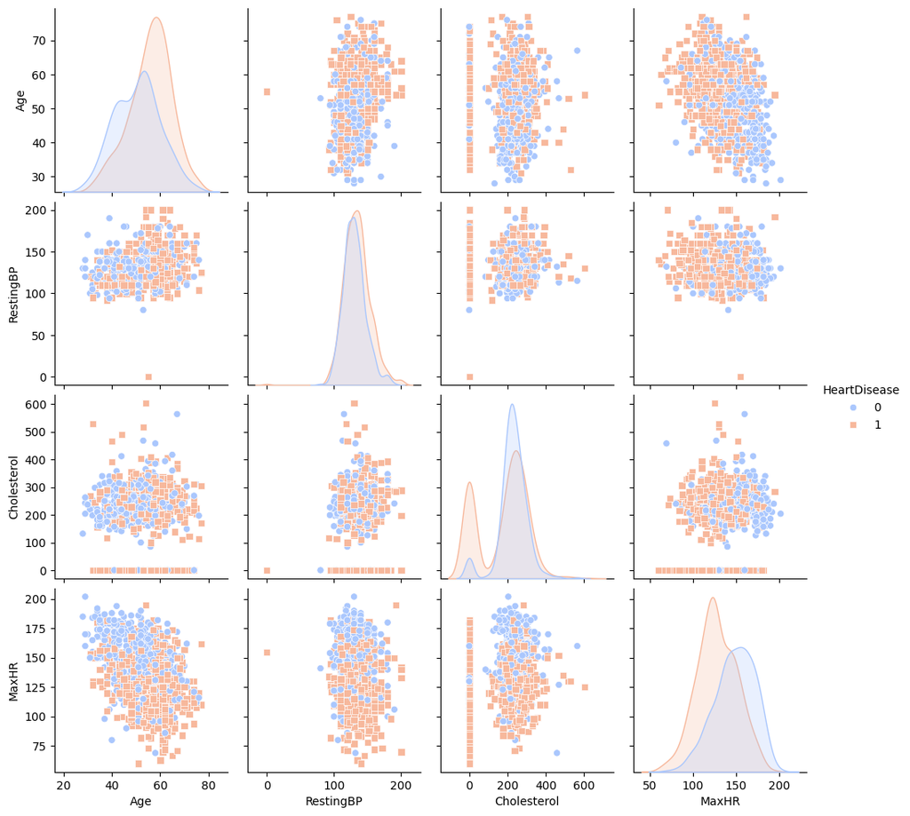

```python
sns.pairplot(bp_df[continuous_vars + ['HeartDisease', 'Sex']], hue='HeartDisease', diag_kind='kde', markers=["o", "s"], palette='coolwarm')
```

```python
print(dp_df)
```

[output not shown]

```python
g.) Create several useful or informative boxplots of continuous variables by category, using Seaborn or PlotNine.   Find an interesting result or contrast
among the variables,   discuss what you think it means or implies

h.) Create violin plots of these same results
```

```python
sns.boxplot(x='HeartDisease', y='RestingBP', data=bp_df, ax=axes[0, 1], palette='coolwarm')
axes[0, 1].set_title('Resting BP by Heart Disease')
axes[0, 1].set_xlabel('Heart Disease')
axes[0, 1].set_ylabel('Resting BP')
```

[output not shown]

```python
1.) Find the mean, median and standard deviation of the Max heartrate variable in this data set

Turn this into a pivot table,   grouping by one or more predictors.
```

```python
maxhr_mean = bp_df['MaxHR'].mean()
maxhr_median = bp_df['MaxHR'].median()
maxhr_std = bp_df['MaxHR'].std()
print(f"Mean of MaxHR: {maxhr_mean}")
print(f"Median of MaxHR: {maxhr_median}")
print(f"Standard Deviation of MaxHR: {maxhr_std}")
```

```
Mean of MaxHR: 136.80936819172112
Median of MaxHR: 138.0
Standard Deviation of MaxHR: 25.460334138250293
```

```python
pivot_table = bp_df.groupby(['HeartDisease', 'Sex'])['MaxHR'].agg(['mean', 'median', 'std'])
```

```python
print(pivot_table)
```

```
                        mean  median        std
HeartDisease Sex
0            F    149.048951   152.0  21.597903
             M    147.670412   150.0  24.170369
1            F    137.820000   142.5  21.820876
             M    126.545852   125.0  23.306611
```